# Project_EDA

# Exploring A Red Wine Dataset by Rashed S.

> This tidy data set contains 1,599 red wines with 11 variables on the chemical properties of the wine. At least 3 wine experts rated the quality of each wine, providing a rating between 0 (very bad) and 10 (very excellent). More info could be found [here](https://s3.amazonaws.com/udacity-hosted-downloads/ud651/wineQualityInfo.txt)

```
## 'data.frame':    1599 obs. of  12 variables:
##  $ fixed.acidity       : num  7.4 7.8 7.8 11.2 7.4 7.4 7.9 7.3 7.8 7.5 ...
##  $ volatile.acidity    : num  0.7 0.88 0.76 0.28 0.7 0.66 0.6 0.65 0.58 0.5 ...
##  $ citric.acid         : num  0 0 0.04 0.56 0 0 0.06 0 0.02 0.36 ...
##  $ residual.sugar      : num  1.9 2.6 2.3 1.9 1.9 1.8 1.6 1.2 2 6.1 ...
##  $ chlorides           : num  0.076 0.098 0.092 0.075 0.076 0.075 0.069 0.065 0.073 0.071 ...
##  $ free.sulfur.dioxide : num  11 25 15 17 11 13 15 15 9 17 ...
##  $ total.sulfur.dioxide: num  34 67 54 60 34 40 59 21 18 102 ...
##  $ density             : num  0.998 0.997 0.997 0.998 0.998 ...
##  $ pH                  : num  3.51 3.2 3.26 3.16 3.51 3.51 3.3 3.39 3.36 3.35 ...
##  $ sulphates           : num  0.56 0.68 0.65 0.58 0.56 0.56 0.46 0.47 0.57 0.8 ...
##  $ alcohol             : num  9.4 9.8 9.8 9.8 9.4 9.4 9.4 10 9.5 10.5 ...
##  $ quality             : int  5 5 5 6 5 5 5 7 7 5 ...
```

```
##  fixed.acidity   volatile.acidity  citric.acid    residual.sugar
##  Min.   : 4.60   Min.   :0.1200   Min.   :0.000   Min.   : 0.900
##  1st Qu.: 7.10   1st Qu.:0.3900   1st Qu.:0.090   1st Qu.: 1.900
##  Median : 7.90   Median :0.5200   Median :0.260   Median : 2.200
##  Mean   : 8.32   Mean   :0.5278   Mean   :0.271   Mean   : 2.539
##  3rd Qu.: 9.20   3rd Qu.:0.6400   3rd Qu.:0.420   3rd Qu.: 2.600
##  Max.   :15.90   Max.   :1.5800   Max.   :1.000   Max.   :15.500
##    chlorides       free.sulfur.dioxide total.sulfur.dioxide
##  Min.   :0.01200   Min.   : 1.00       Min.   :  6.00
##  1st Qu.:0.07000   1st Qu.: 7.00       1st Qu.: 22.00
##  Median :0.07900   Median :14.00       Median : 38.00
##  Mean   :0.08747   Mean   :15.87       Mean   : 46.47
##  3rd Qu.:0.09000   3rd Qu.:21.00       3rd Qu.: 62.00
##  Max.   :0.61100   Max.   :72.00       Max.   :289.00
##     density             pH          sulphates         alcohol
##  Min.   :0.9901   Min.   :2.740   Min.   :0.3300   Min.   : 8.40
##  1st Qu.:0.9956   1st Qu.:3.210   1st Qu.:0.5500   1st Qu.: 9.50
##  Median :0.9968   Median :3.310   Median :0.6200   Median :10.20
##  Mean   :0.9967   Mean   :3.311   Mean   :0.6581   Mean   :10.42
##  3rd Qu.:0.9978   3rd Qu.:3.400   3rd Qu.:0.7300   3rd Qu.:11.10
##  Max.   :1.0037   Max.   :4.010   Max.   :2.0000   Max.   :14.90
##     quality
##  Min.   :3.000
##  1st Qu.:5.000
##  Median :6.000
##  Mean   :5.636
##  3rd Qu.:6.000
##  Max.   :8.000
```

```
##
##   3   4   5   6   7   8
##  10  53 681 638 199  18
```

```
##  fixed.acidity    volatile.acidity  citric.acid     residual.sugar
##  Min.   : 4.600   Min.   :0.1200   Min.   :0.0000   Min.   :0.900
##  1st Qu.: 7.100   1st Qu.:0.3950   1st Qu.:0.0900   1st Qu.:1.900
##  Median : 7.900   Median :0.5200   Median :0.2500   Median :2.200
##  Mean   : 8.259   Mean   :0.5288   Mean   :0.2661   Mean   :2.409
##  3rd Qu.: 9.100   3rd Qu.:0.6400   3rd Qu.:0.4200   3rd Qu.:2.600
##  Max.   :13.200   Max.   :1.5800   Max.   :1.0000   Max.   :8.300
##    chlorides       free.sulfur.dioxide total.sulfur.dioxide
##  Min.   :0.01200   Min.   : 1.00       Min.   :  6.00
##  1st Qu.:0.07000   1st Qu.: 7.00       1st Qu.: 21.25
##  Median :0.07900   Median :13.00       Median : 37.00
##  Mean   :0.08699   Mean   :15.17       Mean   : 44.52
##  3rd Qu.:0.09000   3rd Qu.:21.00       3rd Qu.: 60.00
##  Max.   :0.61100   Max.   :46.00       Max.   :144.00
##     density             pH          sulphates         alcohol      quality
##  Min.   :0.9901   Min.   :2.740   Min.   :0.3300   Min.   : 8.40   3: 10
##  1st Qu.:0.9956   1st Qu.:3.210   1st Qu.:0.5500   1st Qu.: 9.50   4: 52
##  Median :0.9967   Median :3.310   Median :0.6200   Median :10.20   5:650
##  Mean   :0.9967   Mean   :3.316   Mean   :0.6569   Mean   :10.43   6:614
##  3rd Qu.:0.9978   3rd Qu.:3.400   3rd Qu.:0.7275   3rd Qu.:11.10   7:190
##  Max.   :1.0029   Max.   :4.010   Max.   :2.0000   Max.   :14.00   8: 18
```

```
## 'data.frame':    1534 obs. of  12 variables:
##  $ fixed.acidity       : num  7.4 7.8 7.8 11.2 7.4 7.4 7.9 7.3 7.8 7.5 ...
##  $ volatile.acidity    : num  0.7 0.88 0.76 0.28 0.7 0.66 0.6 0.65 0.58 0.5 ...
##  $ citric.acid         : num  0 0 0.04 0.56 0 0 0.06 0 0.02 0.36 ...
##  $ residual.sugar      : num  1.9 2.6 2.3 1.9 1.9 1.8 1.6 1.2 2 6.1 ...
##  $ chlorides           : num  0.076 0.098 0.092 0.075 0.076 0.075 0.069 0.065 0.073 0.071 ...
##  $ free.sulfur.dioxide : num  11 25 15 17 11 13 15 15 9 17 ...
##  $ total.sulfur.dioxide: num  34 67 54 60 34 40 59 21 18 102 ...
##  $ density             : num  0.998 0.997 0.997 0.998 0.998 ...
##  $ pH                  : num  3.51 3.2 3.26 3.16 3.51 3.51 3.3 3.39 3.36 3.35 ...
##  $ sulphates           : num  0.56 0.68 0.65 0.58 0.56 0.56 0.46 0.47 0.57 0.8 ...
##  $ alcohol             : num  9.4 9.8 9.8 9.8 9.4 9.4 9.4 10 9.5 10.5 ...
##  $ quality             : Ord.factor w/ 6 levels "3"<"4"<"5"<"6"<..: 3 3 3 4 3 3 3 5 5 3 ...
```

Looking at the quality the most ratings are 5 shortly followed by 6 with 3 the lowest rating apears to be 3 and 8. We removed the 1% from (Fixed acidity, residual sugar, total sulfur dioxide, and free sulfur dioxide) for having huge outliers

# Univariate Plots Section

Below is a Histogram for each of the variables we have.

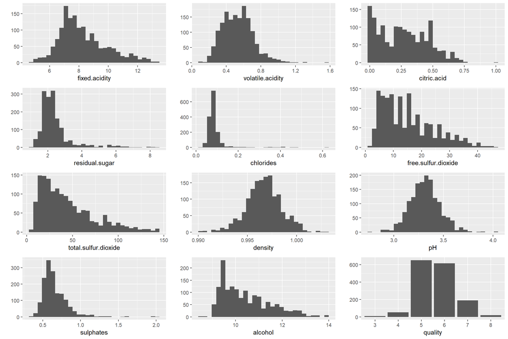

Here we have a compared plots between sulfur dioxide and log10 sulfur dioxide Also we have a compared plots between sulphates and log10 sulphates The log10 is used to make the ploting look cleaner rather than the long tailed one from the normal plots.

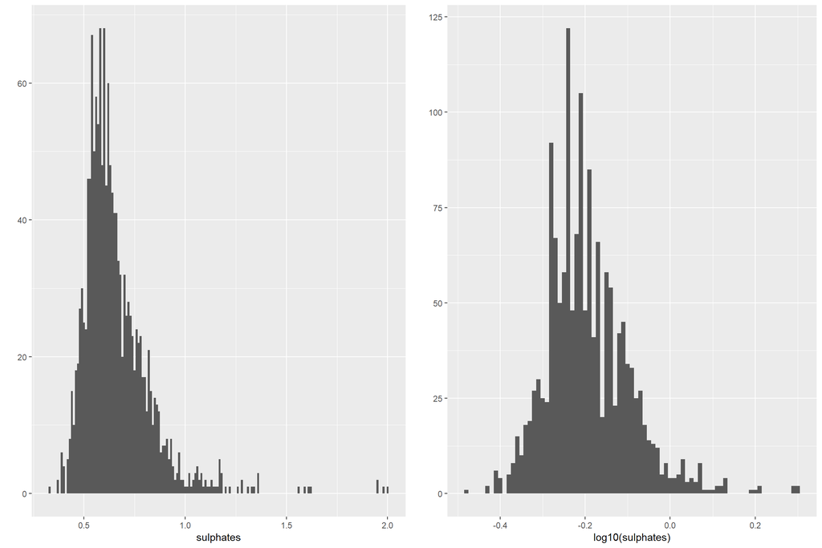

```
##      nbr.val     nbr.null       nbr.na          min          max
## 1.534000e+03 0.000000e+00 0.000000e+00 3.300000e-01 2.000000e+00
##        range          sum       median         mean      SE.mean
## 1.670000e+00 1.007700e+03 6.200000e-01 6.569100e-01 4.339978e-03
## CI.mean.0.95          var      std.dev     coef.var
## 8.512921e-03 2.889351e-02 1.699809e-01 2.587583e-01
```

```
##       nbr.val      nbr.null        nbr.na           min           max
##  1.534000e+03  1.000000e+00  0.000000e+00 -4.814861e-01  3.010300e-01
##         range           sum        median          mean       SE.mean
##  7.825161e-01 -2.979098e+02 -2.076083e-01 -1.942046e-01  2.476082e-03
##  CI.mean.0.95           var       std.dev      coef.var
##  4.856866e-03  9.404925e-03  9.697899e-02 -4.993651e-01
```

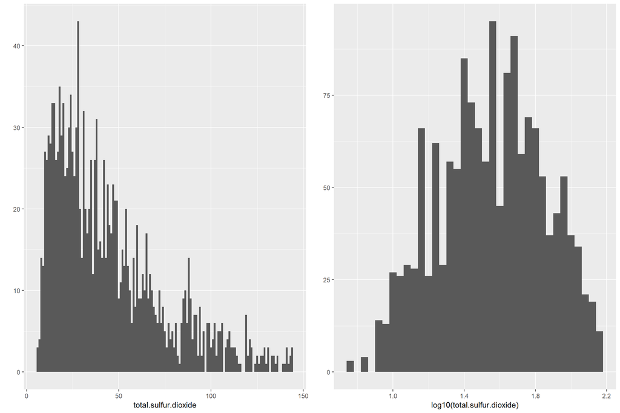

```
##      nbr.val     nbr.null       nbr.na          min          max
## 1.534000e+03 0.000000e+00 0.000000e+00 6.000000e+00 1.440000e+02
##        range          sum       median         mean      SE.mean
## 1.380000e+02 6.829000e+04 3.700000e+01 4.451760e+01 7.624117e-01
## CI.mean.0.95          var      std.dev     coef.var
## 1.495480e+00 8.916706e+02 2.986085e+01 6.707651e-01
```

```
##      nbr.val     nbr.null       nbr.na          min          max
## 1.534000e+03 0.000000e+00 0.000000e+00 7.781513e-01 2.158362e+00
##        range          sum       median         mean      SE.mean
## 1.380211e+00 2.379277e+03 1.568202e+00 1.551028e+00 7.633760e-03
## CI.mean.0.95          var      std.dev     coef.var
## 1.497372e-02 8.939277e-02 2.989862e-01 1.927665e-01
```

Again we compare the log10 for both fixed acidity and volatile acidity to their normal plots to give it a more clean look

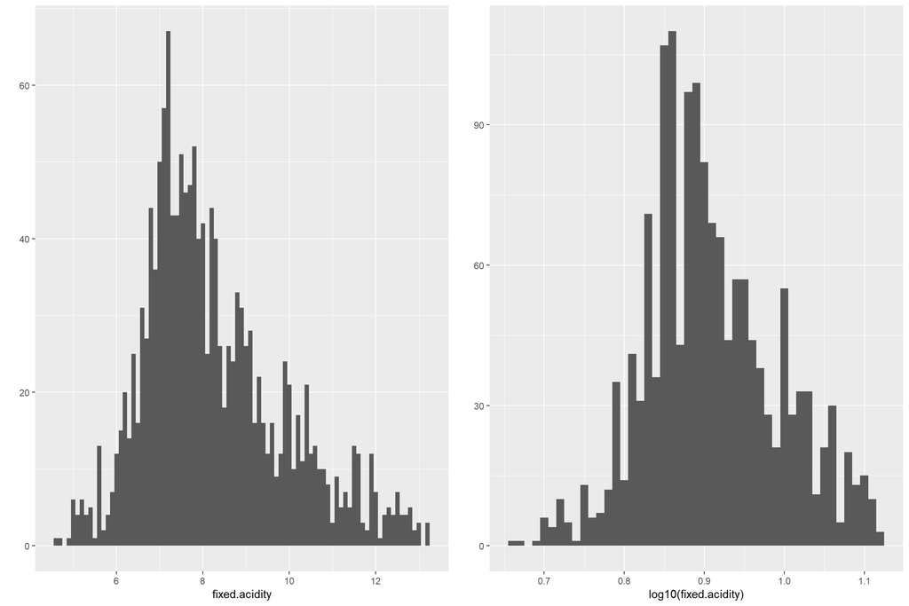

```
##      nbr.val     nbr.null       nbr.na          min          max
## 1.534000e+03 0.000000e+00 0.000000e+00 4.600000e+00 1.320000e+01
##        range          sum       median         mean      SE.mean
## 8.600000e+00 1.266870e+04 7.900000e+00 8.258605e+00 4.167883e-02
## CI.mean.0.95          var      std.dev     coef.var
## 8.175356e-02 2.664750e+00 1.632406e+00 1.976612e-01
```

```
##      nbr.val     nbr.null       nbr.na          min          max
## 1.534000e+03 0.000000e+00 0.000000e+00 6.627578e-01 1.120574e+00
##        range          sum       median         mean      SE.mean
## 4.578161e-01 1.394122e+03 8.976271e-01 9.088150e-01 2.124008e-03
## CI.mean.0.95          var      std.dev     coef.var
## 4.166269e-03 6.920504e-03 8.318956e-02 9.153630e-02
```

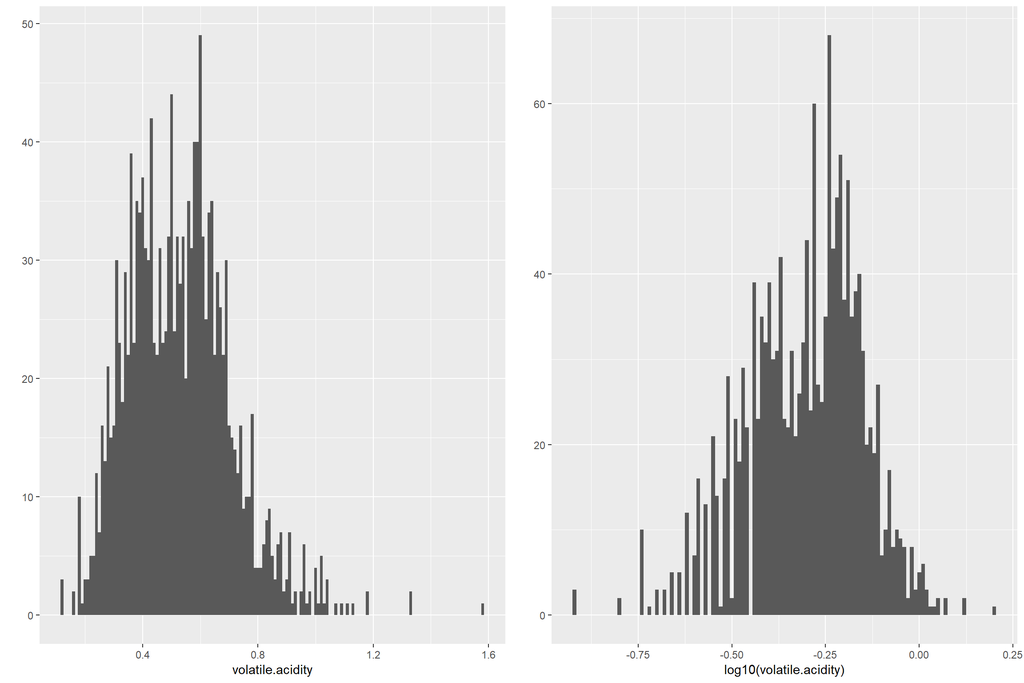

```
##      nbr.val     nbr.null       nbr.na          min          max
## 1.534000e+03 0.000000e+00 0.000000e+00 1.200000e-01 1.580000e+00
##        range          sum       median         mean      SE.mean
## 1.460000e+00 8.111800e+02 5.200000e-01 5.288005e-01 4.533375e-03
## CI.mean.0.95          var      std.dev     coef.var
## 8.892273e-03 3.152599e-02 1.775556e-01 3.357705e-01
```

```
##       nbr.val      nbr.null        nbr.na           min           max
##  1.534000e+03  3.000000e+00  0.000000e+00 -9.208188e-01  1.986571e-01
##         range           sum        median          mean       SE.mean
##  1.119476e+00 -4.633255e+02 -2.839967e-01 -3.020375e-01  3.882498e-03
##  CI.mean.0.95           var       std.dev      coef.var
##  7.615568e-03  2.312319e-02  1.520631e-01 -5.034577e-01
```

We removed the 0 valued critic acid and compare it to the quality to see if it effects our dataset, turns out it is not drastically changed.

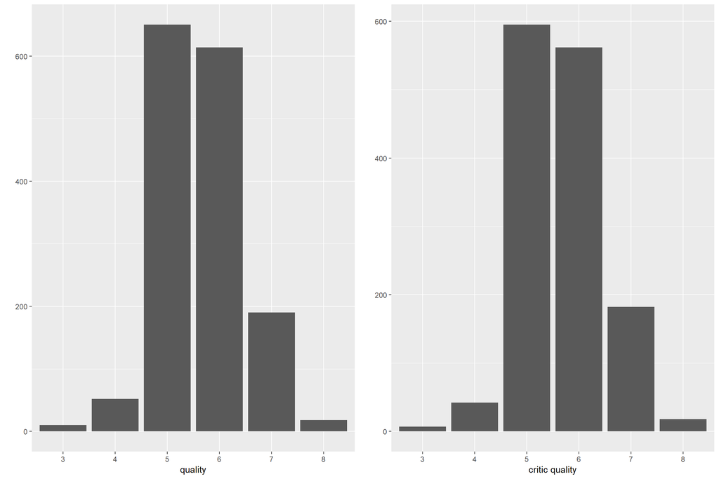

Next we are going to categorize the quality into Bad, Avarage, and Excellent based on the ratings. Bellow we notice that the majority of the ratings are Avarage.

```
##       bad   average excellent
##        62      1264       208
```

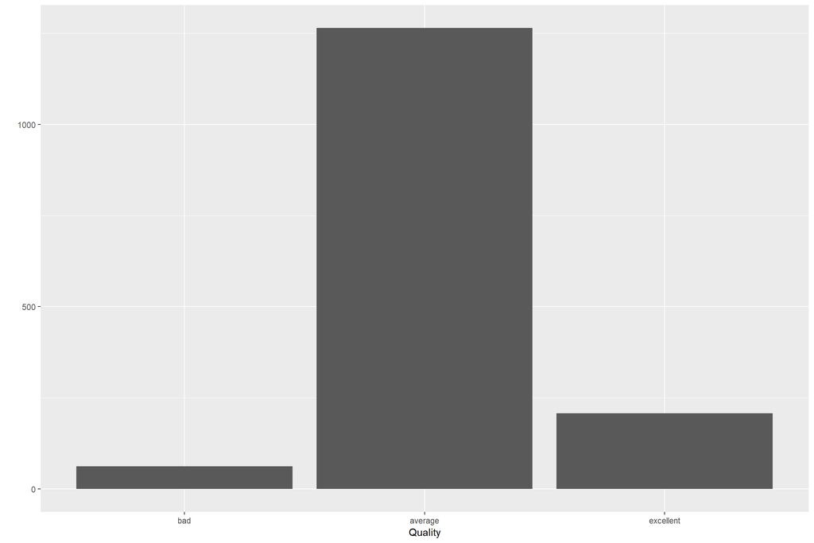

# Univariate Analysis

### What is the structure of your dataset?

The dataset contains 1534 observations and 13 variabls after taking care of the top 1% which had massive outliers(fixed acidity, residual sugar, total sulfur dioxide, and free sulfur dioxide).

### What is/are the main feature(s) of interest in your dataset?

The main focus is the quality of the red wine, I am highly interested in wine and knowing what makes the quality better is my main focus.

### What other features in the dataset do you think will help support your investigation into your feature(s) of interest?

I believe the residual sugar, density, alchol, and ph will help determain the quality more.

### Did you create any new variables from existing variables in the dataset?

Yes in the previous section I created a sub category for the ratings; bad, avarage, excellent.

# Bivariate Plots Section

Bellow is a correlation matrix to see the relations between variabls

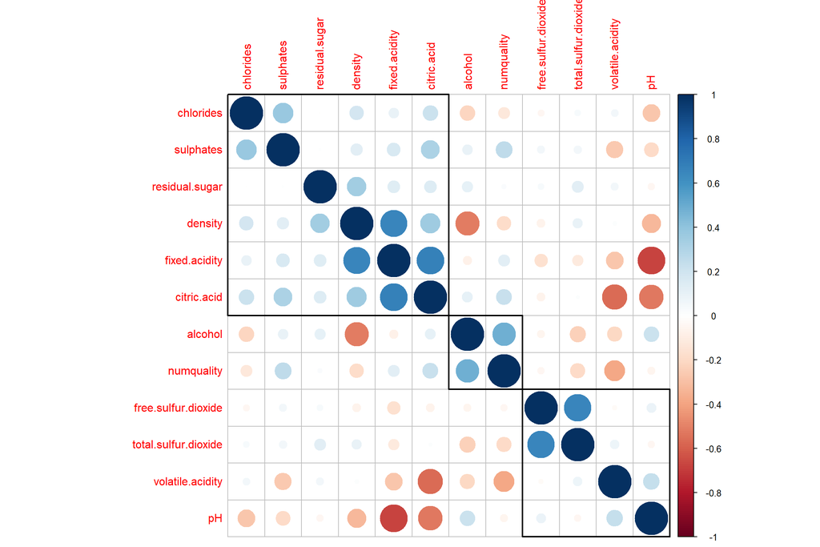

Bellow is a scatterplot between fixed acidity and ph. The correlation coefficient is -0.67 which indicates that the ph rate drops when the fixed acidity increases.

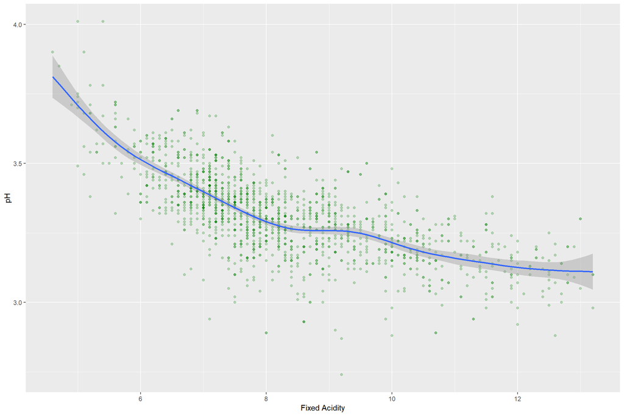

```
## [1] -0.6794406
```

Next we look at the correlation between critic acid and ph. which is -0.52(weaker than the previous fixed acidity)

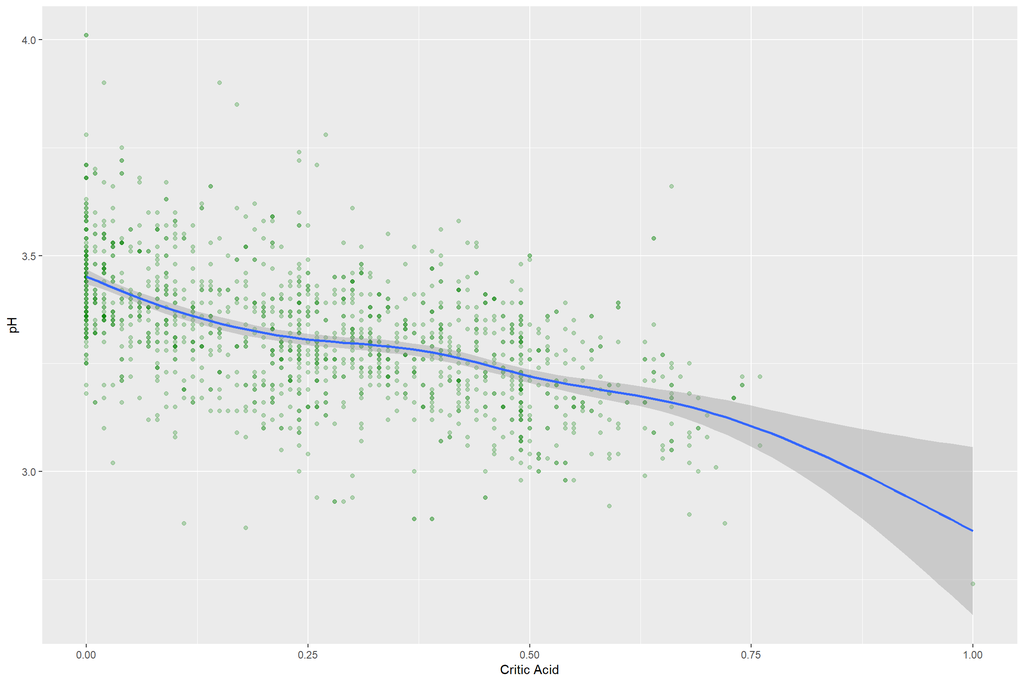

```
## [1] -0.5283267
```

Now we look at the correlation coefficient between volatile acidity and ph which is 0.238 a positive value indicating that the volatile acidity increases when ph level increase.

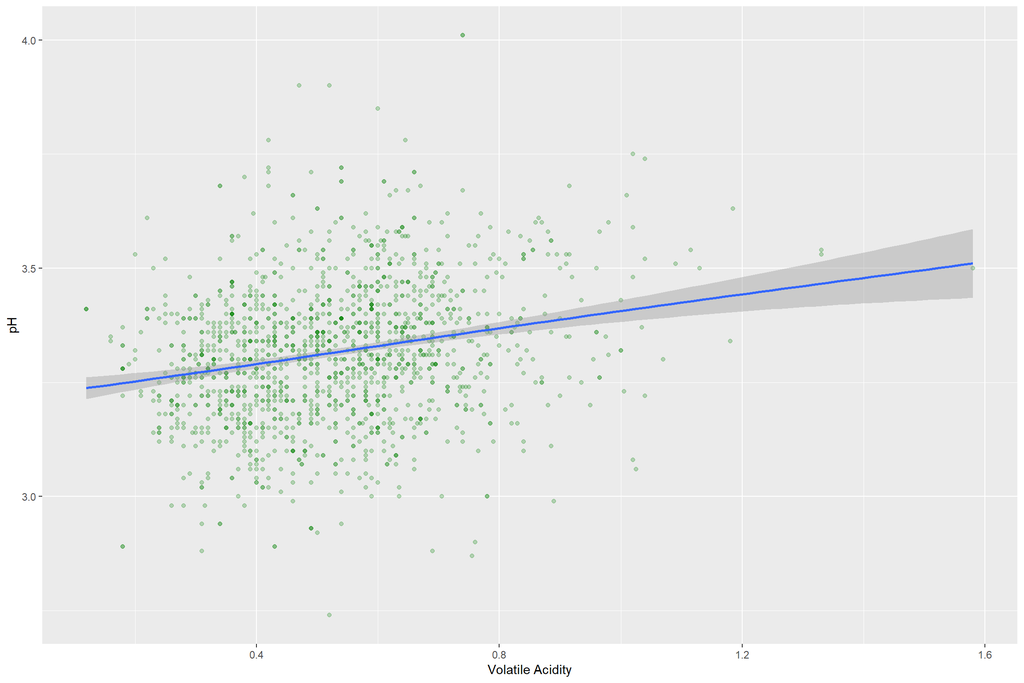

```
## [1] 0.2387919
```

The bellow plot is a boxplot to show the relation between the quality and the ph level. The center x is the median since its more acurate than the mean. median for the bad is the highest 3.38, but overall they’re close.

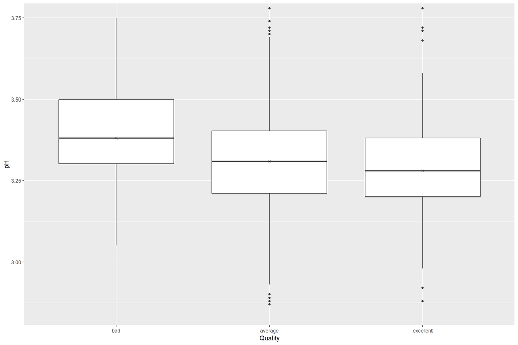

```
## rw$rating: bad
##    Min. 1st Qu.  Median    Mean 3rd Qu.    Max.
##   2.740   3.303   3.380   3.385   3.500   3.900
## --------------------------------------------------------
## rw$rating: average
##    Min. 1st Qu.  Median    Mean 3rd Qu.    Max.
##   2.870   3.210   3.310   3.315   3.402   4.010
## --------------------------------------------------------
## rw$rating: excellent
##    Min. 1st Qu.  Median    Mean 3rd Qu.    Max.
##   2.880   3.200   3.280   3.295   3.380   3.780
```

Like we did before we look at the boxplot of alcohol the median rating for bad is 10, avarage 10, and the excellent the highest median 11.6. we note that the bad and average are the same where the excellent is the highest.

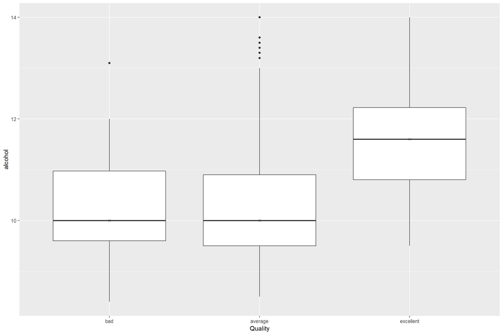

```
## rw$rating: bad
##    Min. 1st Qu.  Median    Mean 3rd Qu.    Max.
##    8.40    9.60   10.00   10.20   10.97   13.10
## --------------------------------------------------------
## rw$rating: average
##    Min. 1st Qu.  Median    Mean 3rd Qu.    Max.
##    8.50    9.50   10.00   10.26   10.90   14.00
## --------------------------------------------------------
## rw$rating: excellent
##    Min. 1st Qu.  Median    Mean 3rd Qu.    Max.
##    9.50   10.80   11.60   11.54   12.22   14.00
```

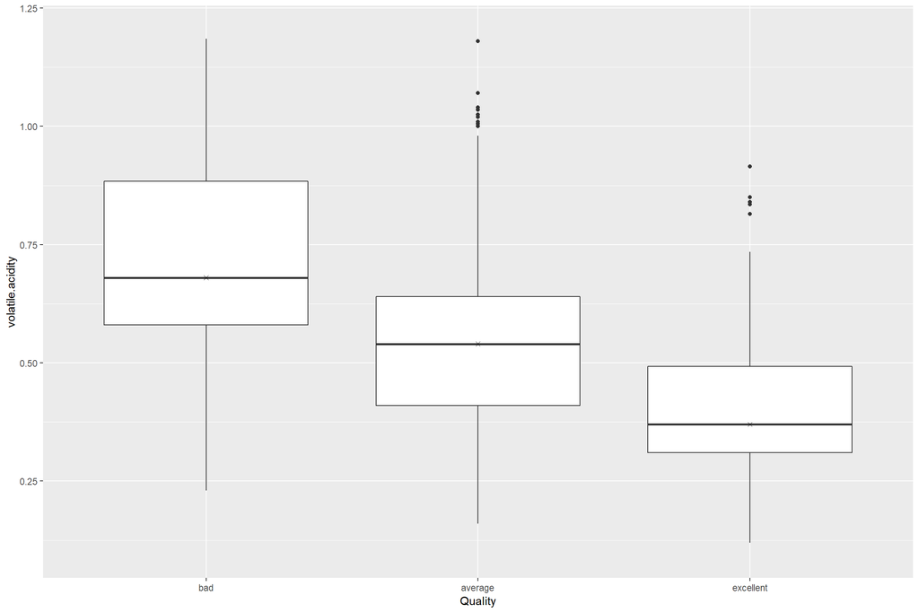

```
## rw$rating: bad
##    Min. 1st Qu.  Median    Mean 3rd Qu.    Max.
##  0.2300  0.5800  0.6800  0.7306  0.8838  1.5800
## --------------------------------------------------------
## rw$rating: average
##    Min. 1st Qu.  Median    Mean 3rd Qu.    Max.
##  0.1600  0.4100  0.5400  0.5386  0.6400  1.3300
## --------------------------------------------------------
## rw$rating: excellent
##    Min. 1st Qu.  Median    Mean 3rd Qu.    Max.
##  0.1200  0.3100  0.3700  0.4090  0.4925  0.9150
```

boxplot of critic acid quality with the central median. Bad 0.075, average 0.24, excellent 0.39. by far the hgihest ratings with weak bad rating.

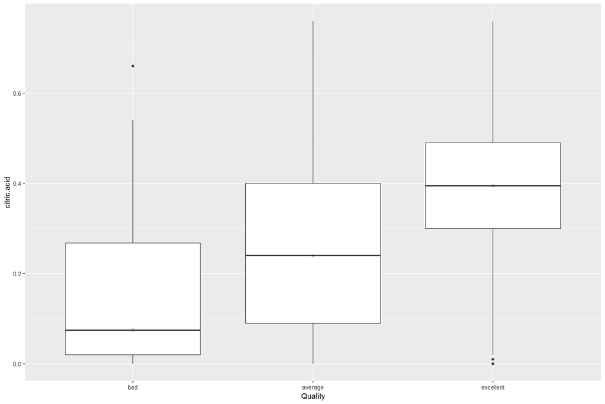

```
## rw$rating: bad
##    Min. 1st Qu.  Median    Mean 3rd Qu.    Max.
##  0.0000  0.0200  0.0750  0.1713  0.2675  1.0000
## --------------------------------------------------------
## rw$rating: average
##    Min. 1st Qu.  Median    Mean 3rd Qu.    Max.
##  0.0000  0.0900  0.2400  0.2538  0.4000  0.7600
## --------------------------------------------------------
## rw$rating: excellent
##    Min. 1st Qu.  Median    Mean 3rd Qu.    Max.
##  0.0000  0.3000  0.3950  0.3687  0.4900  0.7600
```

Boxplot of the sulphates quality with a center median. The bad median 0.56, average 0.61, excellent 0.74. An excellent rating showing.

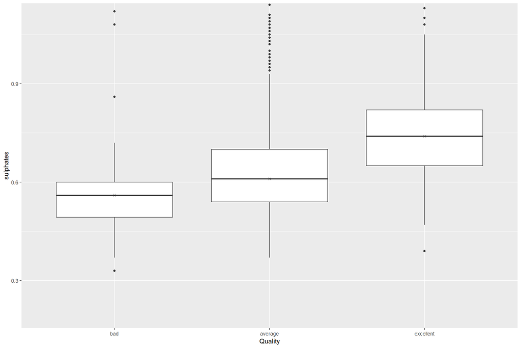

```
## rw$rating: bad
##    Min. 1st Qu.  Median    Mean 3rd Qu.    Max.
##  0.3300  0.4925  0.5600  0.5927  0.6000  2.0000
## --------------------------------------------------------
## rw$rating: average
##    Min. 1st Qu.  Median    Mean 3rd Qu.    Max.
##  0.3700  0.5400  0.6100  0.6457  0.7000  1.9800
## --------------------------------------------------------
## rw$rating: excellent
##    Min. 1st Qu.  Median    Mean 3rd Qu.    Max.
##  0.3900  0.6500  0.7400  0.7444  0.8200  1.3600
```

Bellow is the critc acid vs the log10 sulphates. We notice that the higher critic acid the higher is the sulphate which indecates a correlation. we note that the correlation is 0.33 which is positive.

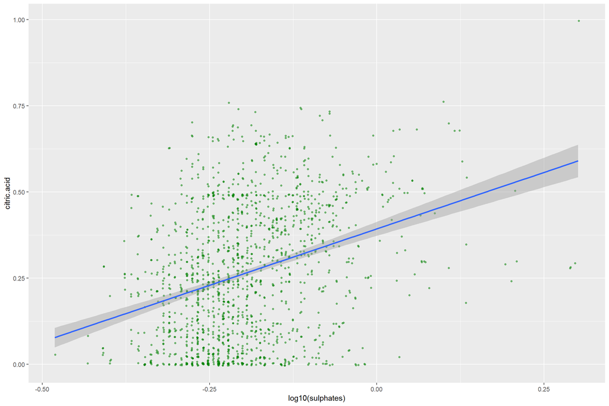

```
## [1] 0.3302825
```

critic acid vs the volatile acidity plot that shows the relation between the two. the correlation coefficient is -0.56 which makes sense since the wine most likely not to have two high acids in the making.

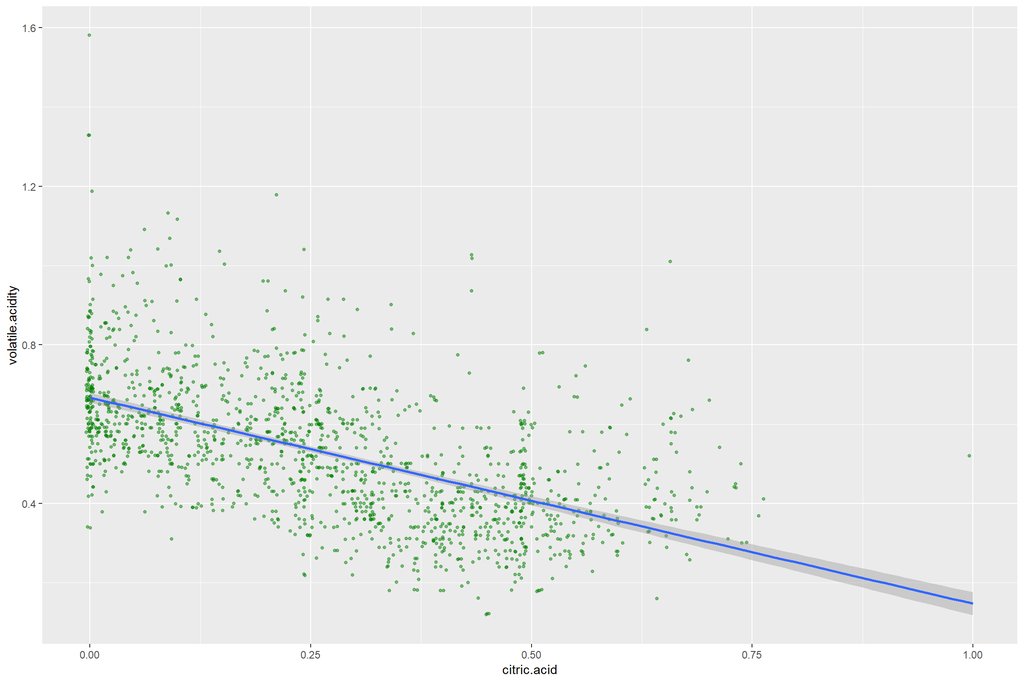

```
## [1] -0.5629224
```

the plot bellow shows the relations between the ph and alchol and its around 0.21 which is weak positive.

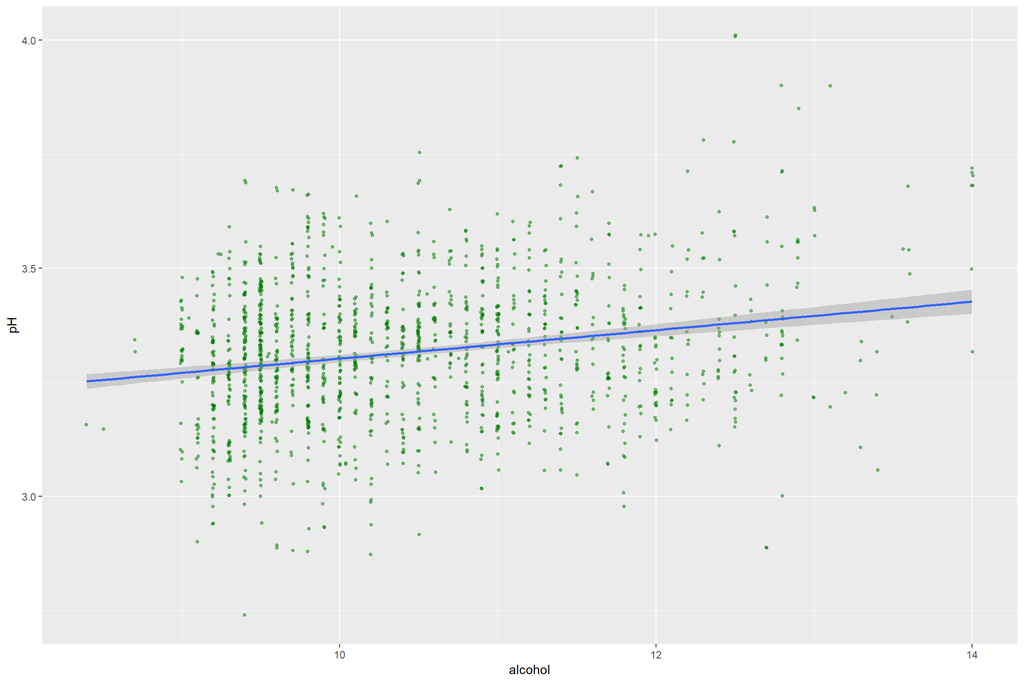

```
## [1] 0.2166557
```

# Bivariate Analysis

### Talk about some of the relationships you observed in this part of the . How did the feature(s) of interest vary with other features in dataset?

The sulphates and the citic acid seems to be in high amounts which indecates that they’re correlated. The volatile acidity and the critic acid are negatively correlated. The correlation between the critic acid and ph level are also negative. Alcohol and ph were weakly correlated.

In the boxplots we took a look at the quality of ph, critic acid, alcohol, volatile acid, and sulphates. The results were interesting. The ph didnt show much change between the ratings(reference the boxplot for ph). The critic acid showed the highest median for the excellent ratings with the 0.39 median(reference the boxplot for the critic acid). The alcohol median showed 11.6 over the two 10 medians of bad and average which shows that the hgiher alcohol the better the wine is. The volatile acidity showed a bad rating of 0.68 vs the excellent 0.37 which shows that the higher the volatile aciddity the worse the wine becomes.

### Did you observe any interesting relationships between the other features (not the main feature(s) of interest)?

crirtc acid and ph level were correlated negatvely, as well as the volatile acididty with the critic acid.

# Multivariate Plots Section

In the scatterplot bellow we look at the alchol vs sulphates and we notice that the average rating quality increases with the increase of sulphates while is excellent ratings the more alcohol(with a specific sulphates) the better the wine.

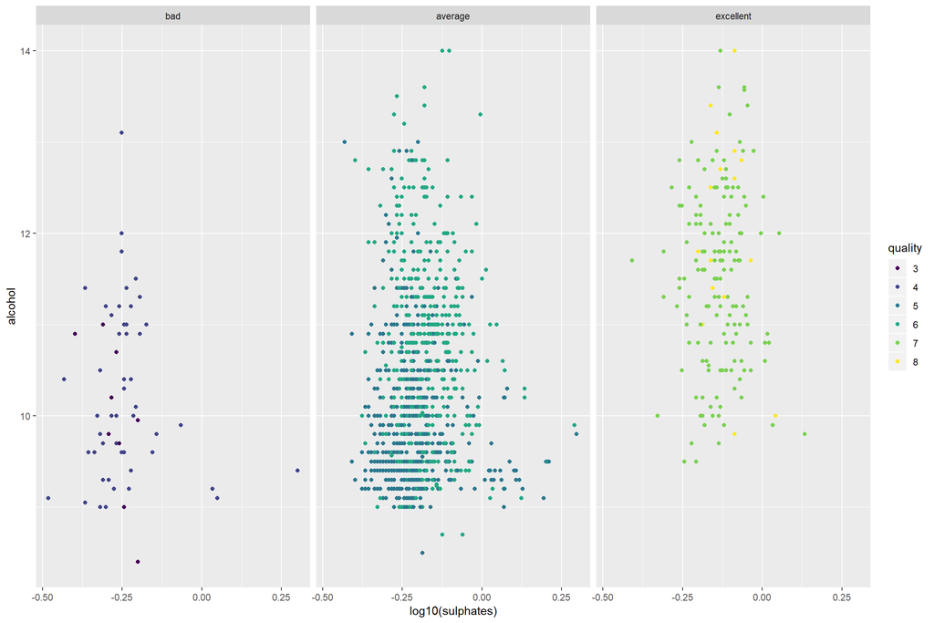

Now we observe the relation between the critic acid vs alcohol we notice that at some critic acid level with higher alcohol the wine get the better rating of excellent.

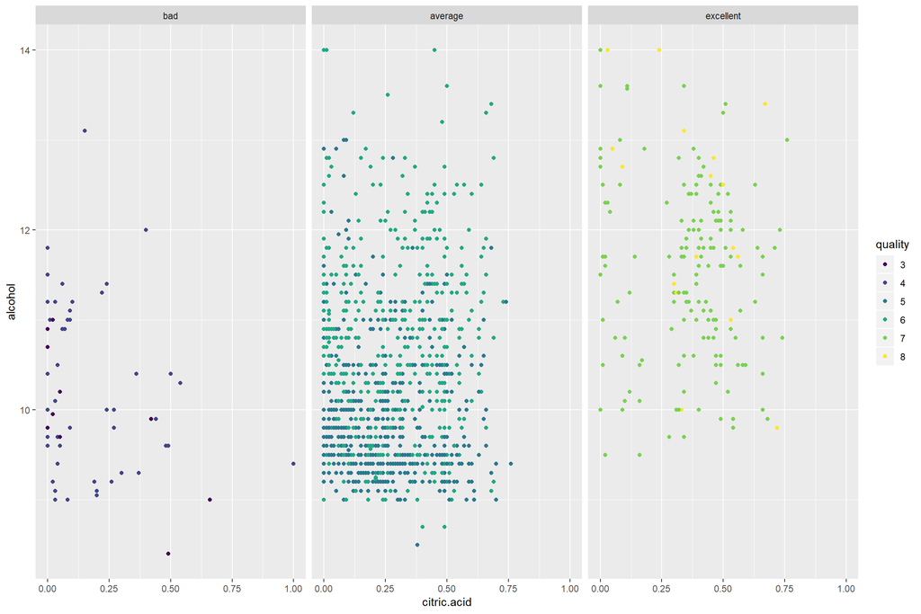

Looking the relations between critic acid and sulphates, we notice that mainly the lower the sulphates the worse the wine gets, however the avarage rating and the bad rating at some cases share the same sulphates which means another variable is responsible for the quality. Excellent quality is great with higher sulphates and critic acid.

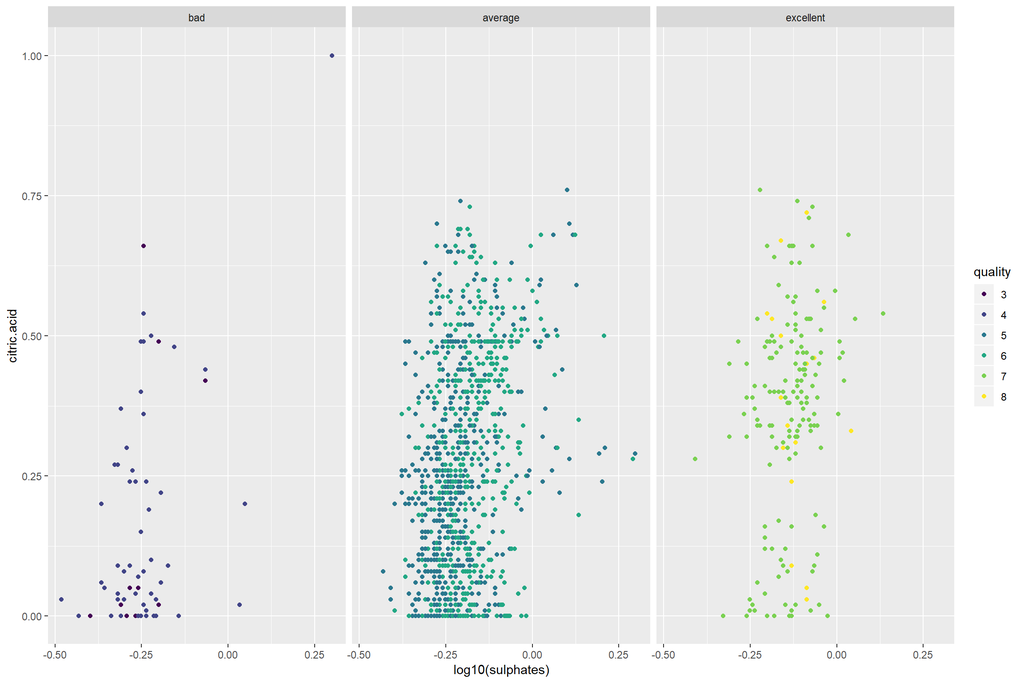

Now lets look at the other variables in relations with critic acid, fist we look at residual sugar vs critic acid. Nothing is too noteworthy between the two.

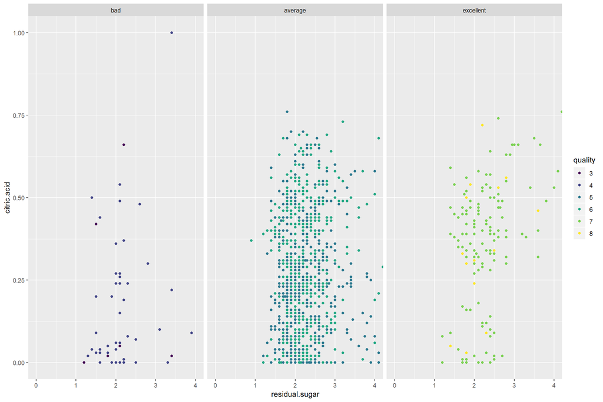

Next we look at the volatile acidity and critic acid.

We notice how when having higher volatile acidity level the worse the wine gets. Also the lower the volatile the better the wine.

we had to take a look at the median for both to get a better look. we notice the median for excellent is 0.37 while the median for bad is 0.68 which is a big differance.

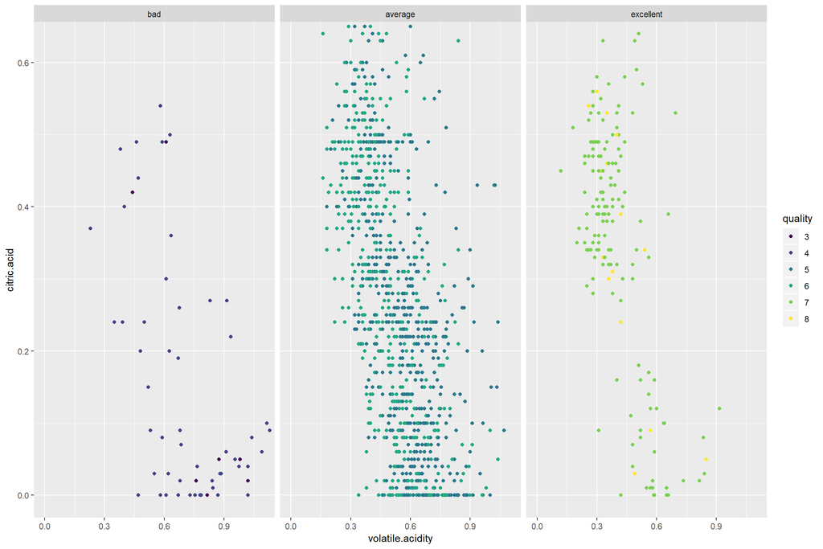

```
## rw$rating: bad
##    Min. 1st Qu.  Median    Mean 3rd Qu.    Max.
##  0.2300  0.5800  0.6800  0.7306  0.8838  1.5800
## --------------------------------------------------------
## rw$rating: average
##    Min. 1st Qu.  Median    Mean 3rd Qu.    Max.
##  0.1600  0.4100  0.5400  0.5386  0.6400  1.3300
## --------------------------------------------------------
## rw$rating: excellent
##    Min. 1st Qu.  Median    Mean 3rd Qu.    Max.
##  0.1200  0.3100  0.3700  0.4090  0.4925  0.9150
```

since the volatile acidity had an interesting results we compare it with alcohol. we notice that the higher volatile acidity is still effecting the bad wine even with higher alcohol

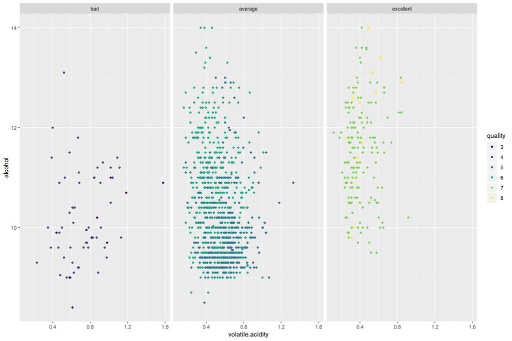

Since the higher sulphates meant better wine and lower volatile acidity meant better wine we look at the relations between the two.

This strengthen our observation, the wine with higher sulphates AND lower volatile acidity is a better wine while the wine with lower sulphates AND higher volatile acidity is bad.

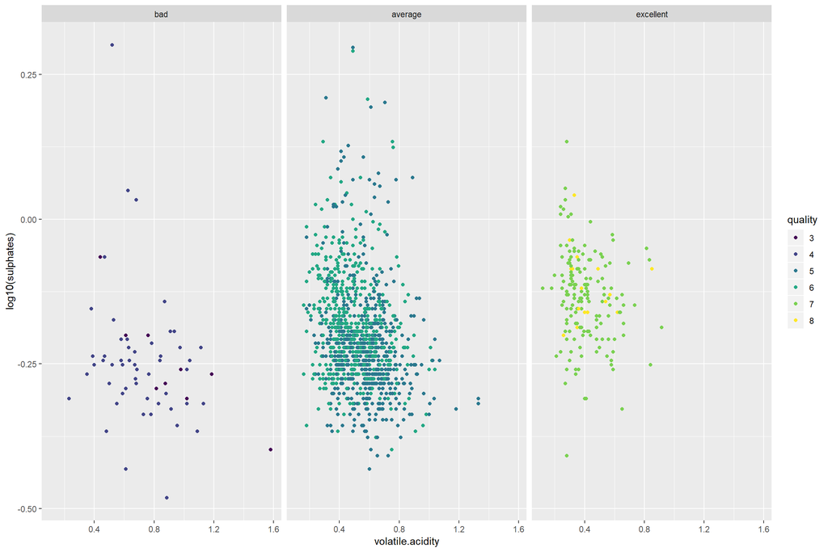

# Multivariate Analysis

### Were there any interesting or surprising interactions between features?

It seems that lower sulphates, higher volatile acidity, lower alcohol and ciritic acid usually made for a bad wine.

### OPTIONAL: Did you create any models with your dataset? Discuss the strengths and limitations of your model.

No.

# Final Plots and Summary

### Plot One

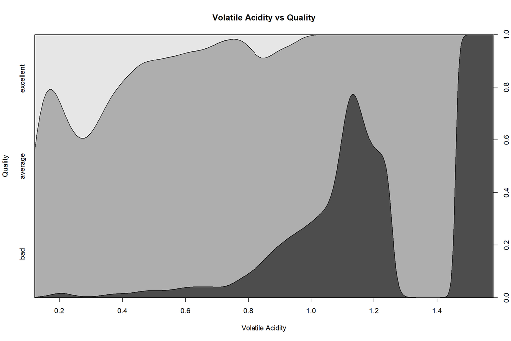

### Description One

As we can observe from the plot the greater the volatile acidity is the greater the chance of the excellent rating DROPS. And the lower the volatile acidity is the better the wine gets. In the plot volatile acidity that is greater than 1.4 has 100% chance of being bad which conferms the findings.

### Plot Two

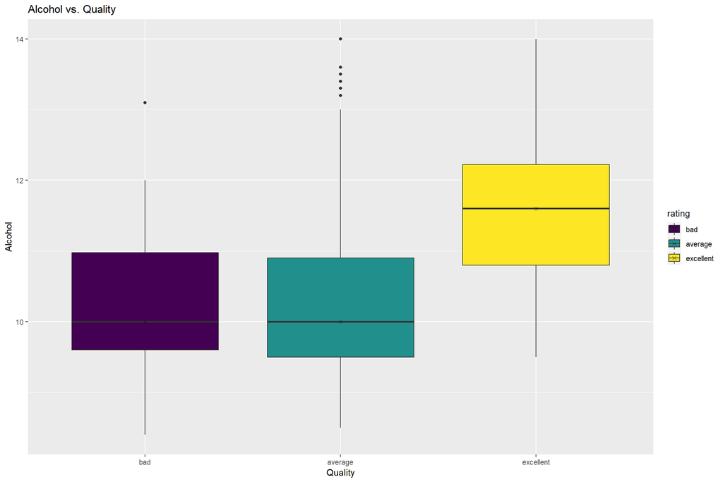

### Description Two

In the Boxplot above, its clear how the higher alcohol effects the quality of the wine positively.

### Plot Three

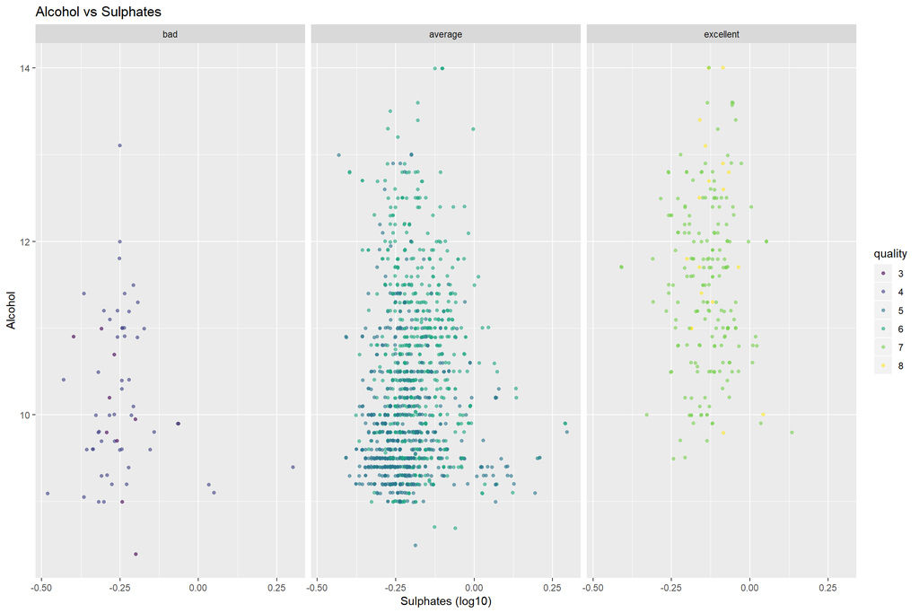

### Description Three

According to the scatter plot above the lower sulpahtes makes a bad wine as well as the lower alcohol. The higher the sulphates and alcohol makes an excellent wine. Its clear how these two effect the quality of the wine.

# Reflection

The red wine dataset contains around 1500+ observations with 13 variables. The main objective of the study is determain the quality of the wine and what makes the wine good. we devided the ratings to bad, avarage, excellent. this was our main track. we looked at the chemical componant of the wine and dived into the making of the wine, which is better and which is bad?

Turns out that the alcohol level played a big role into this, for having a higher alcohol indicated having a better wine, however alcohol alone cant determain the quality. I had to look into other variables such as critic acid and sulphates. It turns out to be successful. The higher critic and sulphates in specif range made for a great wine. Finally I looked at the volatile acidity which indicated the lower it was the better the wine was.

## Struggles:

The dataset was limited to few variables only and I was hoping for more variables to further strenthen my findings. A lot of variables that I studied led to dead ends which always sucks expecially if you spend long time on them.